# Chart: Violin Plot

*This chapter originated as a community contribution created by AshwinJay101*

*This page is a work in progress. We appreciate any input you may have. If you would like to help improve this page, consider contributing to our repo.*

## Overview

This section covers how to make violin plots.

## Some Examples in R

Let’s use the `chickwts` dataset from the `datasets` package to plot a violin plot using `ggplot2`.

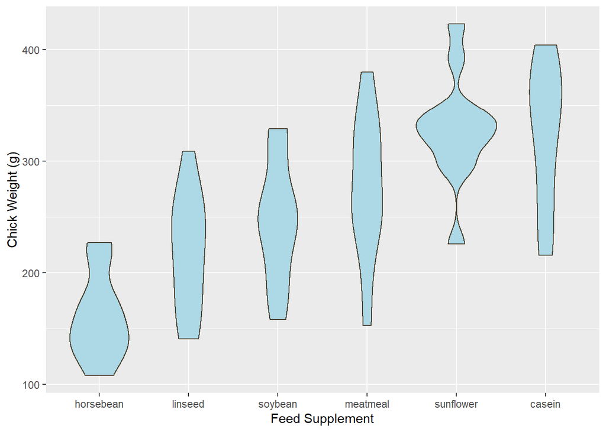

Here’s the code for that:

```r
# import ggplot and the Datasets Package
library(datasets)
library(ggplot2)
supps <- c("horsebean", "linseed", "soybean", "meatmeal", "sunflower", "casein")
# plot data
ggplot(chickwts, aes(x = factor(feed, levels = supps),
                     y = weight)) +
  # plotting
  geom_violin(fill = "lightBlue", color = "#473e2c") +
  labs(x = "Feed Supplement", y = "Chick Weight (g)")
```